# Final Analysis Report

202016222 통계학과 류태영

2025-03-28

```r
knitr::opts_chunk$set(echo = TRUE, message = FALSE, warning = FALSE)
library(rmarkdown)
library(flexdashboard)
library(tidyverse)
library(dplyr)
library(magrittr)
```

```r
library(DT)
library(plotly)
```

# 서론

본 보고서는 **iris 데이터셋**을 대상으로 기본 통계량, 변수 간 상관관계, 그리고 간단한 선형 회귀 분석을 수행한 결과를 정리한 것입니다.  
iris 데이터셋은 붓꽃(Iris)의 종(Species)별로 꽃받침(Sepal)과 꽃잎(Petal)의 길이 및 너비를 측정한 데이터로, 각 변수 간의 관계를 분석하기에 적합한 예제 데이터입니다.

# 데이터 탐색 및 기술 통계

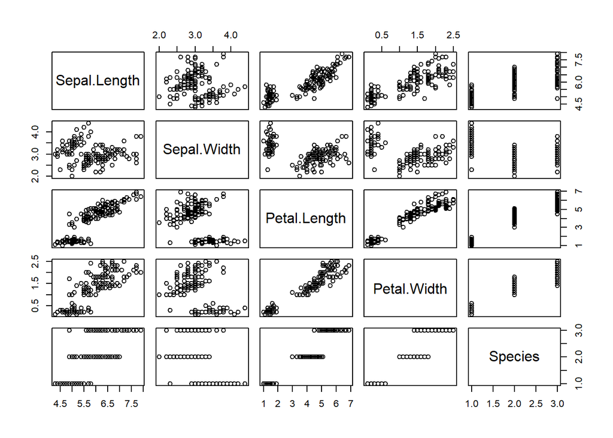

```r
data_name <- params$dataset
data <- get(data_name)

# iris 데이터셋인 경우에만 분석 코드 실행
if(data_name == "iris"){
  summary(data)
  plot(data)
} else {
  # iris 데이터셋이 아닐 경우: 아무 작업도 수행하지 않음
}
```

# 변수 간 상관관계 분석

- **목적**: 수치형 변수들 간의 상관관계를 분석하여 변수들 간의 관계 강도와 방향을 파악합니다.
- **분석 방법**: iris 데이터셋의 꽃받침 및 꽃잎 관련 변수들(첫 4개 변수) 간의 상관계수 행렬을 계산하고, 이를 반올림하여 확인합니다.

```r
if(data_name == "iris"){
  cor_matrix <- cor(data[, 1:4])
  round(cor_matrix, 2)
} else {
  # iris 데이터셋이 아닐 경우: 아무 작업도 수행하지 않음
}
```

```
##              Sepal.Length Sepal.Width Petal.Length Petal.Width
## Sepal.Length         1.00       -0.12         0.87        0.82
## Sepal.Width         -0.12        1.00        -0.43       -0.37
## Petal.Length         0.87       -0.43         1.00        0.96
## Petal.Width          0.82       -0.37         0.96        1.00
```

- **Sepal.Length와 Petal.Length**: 상관계수 0.87 → 강한 양의 상관관계
- **Petal.Length와 Petal.Width**: 상관계수 0.96 → 매우 강한 양의 상관관계
- **Sepal.Length와 Petal.Width**: 상관계수 0.82 → 유의미한 양의 관계
- **Sepal.Width**: 다른 변수들과 비교하여 상대적으로 낮은 상관관계 또는 음의 상관관계를 보임

# 선형 회귀 분석

- **목적**: 꽃잎 길이(Petal.Length)를 종속 변수로, 꽃받침 길이(Sepal.Length)를 독립 변수로 하여, 두 변수 간의 선형 관계를 검증합니다.
- **분석 방법**: 선형 회귀 모델을 생성한 후, 회귀 계수와 유의성(예: p-value)을 평가합니다.

```r
if(data_name == "iris"){
  model <- lm(Petal.Length ~ Sepal.Length, data = data)
  summary(model)
} else {
  # iris 데이터셋이 아닐 경우: 아무 작업도 수행하지 않음
}
```

```
##
## Call:
## lm(formula = Petal.Length ~ Sepal.Length, data = data)
##
## Residuals:
##      Min       1Q   Median       3Q      Max
## -2.47747 -0.59072 -0.00668  0.60484  2.49512
##
## Coefficients:
##              Estimate Std. Error t value Pr(>|t|)
## (Intercept)  -7.10144    0.50666  -14.02   <2e-16 ***
## Sepal.Length  1.85843    0.08586   21.65   <2e-16 ***
## ---
## Signif. codes:  0 '***' 0.001 '**' 0.01 '*' 0.05 '.' 0.1 ' ' 1
##
## Residual standard error: 0.8678 on 148 degrees of freedom
## Multiple R-squared:   0.76,  Adjusted R-squared:  0.7583
## F-statistic: 468.6 on 1 and 148 DF,  p-value: < 2.2e-16
```

- **Intercept (-7.10)**: 꽃받침 길이가 0일 때의 예상 꽃잎 길이
- **Sepal.Length 계수 (1.86)**: 꽃받침 길이가 1 단위 증가할 때마다 꽃잎 길이가 평균적으로 1.86 단위 증가
- **R² (약 0.76)**: 꽃받침 길이가 꽃잎 길이 변동의 약 76%를 설명
- **p-value (< 2e-16)**: 통계적으로 매우 유의미함

# 시각화 및 대시보드

- **Flexdashboard 활용**: Flexdashboard 레이아웃을 사용하여 인터랙티브 산점도와 데이터 테이블을 구성합니다.
- **인터랙티브 기능**:
  - HTML 출력 시, `plotly`를 사용하여 인터랙티브 산점도를 제공하고,
  - `DT` 패키지를 통해 인터랙티브 데이터 테이블을 구현합니다.
- **PDF/Word 출력**: 인터랙티브 요소 대신 정적 플롯과 표(knitr::kable())를 사용하여 결과를 표시합니다.

```r
if(data_name == "iris"){
  # iris 데이터셋에서 모든 종을 선택한 후, 상위 50행만 사용
  selected_species <- unique(data$Species)
  filtered_data <- data %>%
    filter(Species %in% selected_species) %>%
    head(50)

  p <- ggplot(filtered_data, aes(x = Sepal.Length, y = Petal.Length, color = Species)) +
    geom_point(size = 3, alpha = 0.8) +
    labs(title = "Iris 데이터 산점도", x = "Sepal Length", y = "Petal Length") +
    theme_minimal()

  if (knitr::is_html_output()) {
    ggplotly(p)
  } else {
    p
  }
} else {
  # iris 데이터셋이 아닐 경우: 아무 작업도 수행하지 않음
}
```

[interactive chart not shown]

```r
if(data_name == "iris"){
  if (knitr::is_html_output()) {
    DT::datatable(filtered_data)
  } else {
    knitr::kable(filtered_data)
  }
} else {
  # iris 데이터셋이 아닐 경우: 아무 작업도 수행하지 않음
}
```

|  | Sepal.Length | Sepal.Width | Petal.Length | Petal.Width | Species |
| --- | --- | --- | --- | --- | --- |
| 1 | 5.1 | 3.5 | 1.4 | 0.2 | setosa |
| 2 | 4.9 | 3 | 1.4 | 0.2 | setosa |
| 3 | 4.7 | 3.2 | 1.3 | 0.2 | setosa |
| 4 | 4.6 | 3.1 | 1.5 | 0.2 | setosa |
| 5 | 5 | 3.6 | 1.4 | 0.2 | setosa |
| 6 | 5.4 | 3.9 | 1.7 | 0.4 | setosa |
| 7 | 4.6 | 3.4 | 1.4 | 0.3 | setosa |
| 8 | 5 | 3.4 | 1.5 | 0.2 | setosa |
| 9 | 4.4 | 2.9 | 1.4 | 0.2 | setosa |
| 10 | 4.9 | 3.1 | 1.5 | 0.1 | setosa |

[output cut: 40 more lines]

# 결론

## 의의 및 활용

- 본 보고서는 iris 데이터셋의 특성을 종합적으로 분석함으로써, 변수들 간의 관계와 상호 작용을 심도 있게 이해하는 데 기여합니다.
- 이러한 분석 결과는 향후 데이터 분석 및 모델링 연구에 유용한 기초 자료로 활용될 수 있습니다.